# Test a Perceptual Phenomenon

## Statistics: The Science of Decisions Project Instructions

### Background Information

In a **Stroop task**, participants are presented with a list of words, with each word displayed in a color of ink. The participant’s task is to say out loud the color of the ink in which the word is printed. The task has **two conditions**: **a congruent words condition**, and an **incongruent words condition**. In the congruent words condition, the words being displayed are color words whose names match the colors in which they are printed: for example RED, BLUE. In the incongruent words condition, the words displayed are color words whose names do not match the colors in which they are printed: for example PURPLE, ORANGE. In each case, **we measure the time it takes to name the ink colors** in equally-sized lists. Each participant will go through and record a time from each condition.

## Questions For Investigation

We will investigae the below questions as part of this project.

### 1. What is our independent variable? What is our dependent variable?

**Answer** - From the above background information we can see that we have an independent variables and a dependent variable.

- Independent Variables -> Congruent Words Condition or Incongruent Words Condition
- Dependent Variable -> Time it takes to name the Ink Colors

### 2. What is an appropriate set of hypotheses for this task? What kind of statistical test do you expect to perform? Justify your choices.

**Answer**

- $\mu_{C}$ - Time it takes to name the ink colors for congruent condition.
- $\mu_{I}$ - Time it takes to name the ink colors for incongruent condition.

Appropriate set of hypothesis for this task.

- $H_{o}$ - Time it takes to name the ink colors for congruent condition and incongruent condition is the same.
- $H_{a}$ - Time it takes to name the ink colors for congruent condition and incongruent condition is **not** the same.

The hypothesis can also be stated as below.

- $H_{o}$ - ($\mu_{C}$ - $\mu_{I}$ = 0): There is **no** significant difference in time for the population to state the colors in a congruent or incongruent condition.
- $H_{a}$ - ($\mu_{C}$ - $\mu_{I} \neq$ 0): There is a significant difference in time for the population to state the colors in a congruent or incongruent condition.

Statistical test that can be performed on this data

- We will perform a 2 paired t-test on this data for the below reasons:
  - We are testing a hypothesis.
  - We have a quantitative response variable.
  - We do not know the population standard devaition.
  - We have a sample size less than 30.
  - We have a paired sample.
  - We have 1 treatment variable and 2 categories
  - We have a normally distributed data.

Now it’s your chance to try out the Stroop task for yourself. Go to [this link](https://faculty.washington.edu/chudler/java/ready.html), which has a Java-based applet for performing the Stroop task. Record the times that you received on the task (you do not need to submit your times to the site.) Now, download [this dataset](https://drive.google.com/file/d/0B9Yf01UaIbUgQXpYb2NhZ29yX1U/view) which contains results from a number of participants in the task. Each row of the dataset contains the performance for one participant, with the first number their results on the congruent task and the second number their performance on the incongruent task.

```python
import pandas as pd
import numpy as np

import matplotlib.pyplot as plt

%matplotlib inline
```

```python
# Read the data set
df = pd.read_csv('stroopdata.csv')

# Print the shape of the data
print("Shape of the DataFrame is -> " + str(df.shape))

# Show the data
df.head(n=24)
```

```
Shape of the DataFrame is -> (24, 2)
```

|  | Congruent | Incongruent |
| --- | --- | --- |
| 0 | 12.079 | 19.278 |
| 1 | 16.791 | 18.741 |
| 2 | 9.564 | 21.214 |
| 3 | 8.630 | 15.687 |
| 4 | 14.669 | 22.803 |
| 5 | 12.238 | 20.878 |
| 6 | 14.692 | 24.572 |
| 7 | 8.987 | 17.394 |
| 8 | 9.401 | 20.762 |
| 9 | 14.480 | 26.282 |
| 10 | 22.328 | 24.524 |
| 11 | 15.298 | 18.644 |
| 12 | 15.073 | 17.510 |
| 13 | 16.929 | 20.330 |
| 14 | 18.200 | 35.255 |
| 15 | 12.130 | 22.158 |
| 16 | 18.495 | 25.139 |
| 17 | 10.639 | 20.429 |
| 18 | 11.344 | 17.425 |
| 19 | 12.369 | 34.288 |
| 20 | 12.944 | 23.894 |
| 21 | 14.233 | 17.960 |
| 22 | 19.710 | 22.058 |
| 23 | 16.004 | 21.157 |

```python
# Describe the data
df.describe()
```

|  | Congruent | Incongruent |
| --- | --- | --- |
| count | 24.000000 | 24.000000 |
| mean | 14.051125 | 22.015917 |
| std | 3.559358 | 4.797057 |
| min | 8.630000 | 15.687000 |
| 25% | 11.895250 | 18.716750 |
| 50% | 14.356500 | 21.017500 |
| 75% | 16.200750 | 24.051500 |
| max | 22.328000 | 35.255000 |

### 3. Report some descriptive statistics regarding this dataset. Include at least one measure of central tendency and at least one measure of variability.

```python
# Print measures of central tendency
# mean
print("Measures of central tendency")
print("-----------")
mean_congruent = np.mean(df['Congruent'])
mean_incongruent = np.mean(df['Incongruent'])

print("Mean of Congruent Data -> " + str(mean_congruent))
print("Mean of Incongruent Data -> " + str(mean_incongruent))
print("\n")

# median
median_congruent = np.median(df['Congruent'])
median_incongruent = np.median(df['Incongruent'])

print("Median of Congruent Data -> " + str(median_congruent))
print("Median of Incongruent Data -> " + str(median_incongruent))
print("\n")

# Print measures of variability
# range
print("Measures of Variability")
print("-----------")
range_congruent = np.ptp(df['Congruent'])
range_incongruent = np.ptp(df['Incongruent'])

print("Range of Congruent Data -> " + str(range_congruent))
print("Range of Incongruent Data -> " + str(range_incongruent))
print("\n")

# standard deviation
std_congruent = np.std(df['Congruent'], ddof = 1)
std_incongruent = np.std(df['Incongruent'], ddof = 1)

print("Standard Deviation of Congruent Data -> " + str(std_congruent))
print("Standard Deviation of Incongruent Data -> " + str(std_incongruent))
```

```
Measures of central tendency
-----------
Mean of Congruent Data -> 14.051125000000004
Mean of Incongruent Data -> 22.01591666666667


Median of Congruent Data -> 14.3565
Median of Incongruent Data -> 21.0175


Measures of Variability
-----------
Range of Congruent Data -> 13.698
Range of Incongruent Data -> 19.568


Standard Deviation of Congruent Data -> 3.559357957645195
Standard Deviation of Incongruent Data -> 4.797057122469138
```

### 4. Provide one or two visualizations that show the distribution of the sample data. Write one or two sentences noting what you observe about the plot or plots.

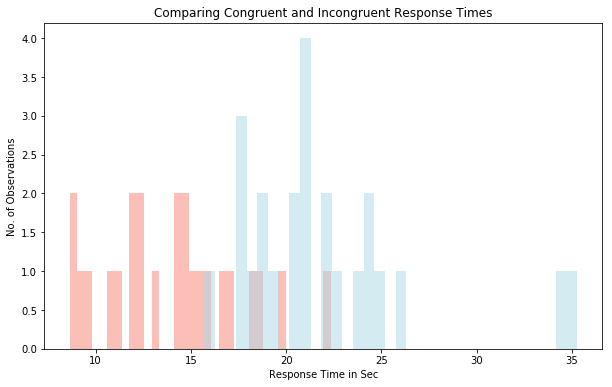

```python
fig, ax = plt.subplots(figsize=(10, 6))

ax.hist(df['Congruent'], bins = 35, color='salmon', alpha=0.5)
ax.hist(df['Incongruent'], bins = 35, color='lightblue', alpha=0.5)

ax.set(title='Comparing Congruent and Incongruent Response Times', ylabel='No. of Observations', xlabel = 'Response Time in Sec')
ax.margins(0.05)
ax.set_ylim(bottom=0)
plt.show()
```

- From the above histogram we could see that Congruent observation times lie between 8 and 22 whereas Incongruent observations lie between 16 and 35.
- Most of the observations for Congruent data lies between 12 and 17. For Incongruent data most of the observations lie between 17 and 25.
- For Incongruent data the 2 extreme data points at 35 seconds could be potential outliers.

We will draw a box plot below to get better insights of the data.

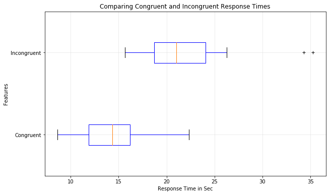

```python
fig, ax = plt.subplots(figsize=(10, 6))

bp = plt.boxplot([df['Congruent'], df['Incongruent']], vert = False, widths = 0.25, labels = ['Congruent', 'Incongruent'])

ax.set(title='Comparing Congruent and Incongruent Response Times', ylabel='Features', xlabel = 'Response Time in Sec')
ax.xaxis.grid(True, linestyle='-', which='major', color='lightgrey', alpha=0.5)
ax.yaxis.grid(True, linestyle='-', which='major', color='lightgrey', alpha=0.5)
plt.setp(bp['boxes'], color='blue')
plt.setp(bp['whiskers'], color='blue')
plt.setp(bp['fliers'], color='green', marker='+')
plt.show()
```

From the above boxplot we could clearly see that Incongruent data indeed has got 2 outliers.

### 5. Now, perform the statistical test and report your results. What is your confidence level and your critical statistic value? Do you reject the null hypothesis or fail to reject it? Come to a conclusion in terms of the experiment task. Did the results match up with your expectations?

We will now perform a t-test on the data to check if we have to "reject the null hypothesis" or "fail to reject the null hypothesis".

- The degrees of freedom for this data is 23 as n = 24
- We will assume a confidence level of 90% for this 2-tailed test.
- The t-critical for df=23 and p=0.10 is $\pm$ 1.714
- Mean of Congruent data points = 14.051
- Mean of Incongruent data points = 22.016
- Point of estimate for $\mu_{C}$ - $\mu_{I}$ = -7.965
- Standard Deviation S = 4.865 and n = 24

$$ \Large t = \frac{\mu_{C} - \mu_{I}}{\frac{S}{\sqrt{n}}} $$

**t-statistical = -8.021**

> As the t-statistical value is less than the t-critical and falls in the critical region we will **reject** the null hypothesis

Rejecting the Null Hypothesis clearly tells us that there is a significant difference between the population average completion time for the Congruent condition and Incongruent conditions. This falls in-line with the test results for my case wherein I took 15 seconds with Congruent condition and around 35 seconds with Incongruent condition.

### 6. Optional: What do you think is responsible for the effects observed? Can you think of an alternative or similar task that would result in a similar effect? Some research about the problem will be helpful for thinking about these two questions!

*What do you think is responsible for the effects observed?* - Without going in to any Mathematical, Physcological or Scientific reasoning we can clearly see that while reading **Congruent words** we are seeing and reading the same thing and thus our brain is doing a single task at a faster speed. But with **Incongruent words** the brain is trying to do two things - reading the word and identifying the color which are different thus affecting the speed with which it can process the things.

There are also Theories like **Processing speed**, **Selective attention**, **Automaticity**, **Parallel distributed processing** that talk about the reasons why there is a difference in reaction time for both the activities.

*Can you think of an alternative or similar task that would result in a similar effect?* - Tasks that would result in a similar effect would be - The Reverse Stroop Effect, Hayling and Brixton tests and Rey–Osterrieth complex figure.

References

1. https://en.wikipedia.org/wiki/Stroop_effect
2. https://onlinecourses.science.psu.edu/statprogram/node/136
3. http://www.efoza.com/postpic/2012/05/statistical-test-flow-chart_237102.jpg
4. https://stats.idre.ucla.edu/spss/whatstat/what-statistical-analysis-should-i-usestatistical-analyses-using-spss/